# Análisis evolución Covid-19 para regiones de Chile (29/03/2020)

Claudio Bustos

29/3/2020

**NOTA**: Lo que presento aquí es un ejemplo de como realizar análisis de series de tiempo, usando datos de la evolución total de casos disponible en fuentes públicas en internet. No tiene ninguna validez epidemiológica, ya que eso requería un modelo de la diseminación de la enfermedad. En particular, las predicciones son solo válidas en cuanto no existan cambios en las políticas públicas; si los hay, se esperaría que (ojalá) las predicciones fuesen incorrectas.

- Reportes anteriores: https://github.com/clbustos/analisis_covid19_chile

Comentario personal: Mañana tengo que entregar un informe gigante, así que solo pondré los gráficos. Mañana volvemos en regla.

## Análisis de datos observados

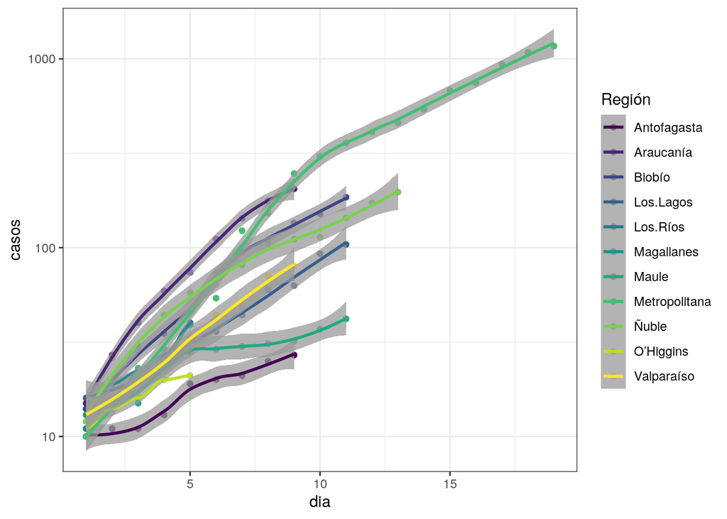

El mismo gráfico, pero separando las regiones

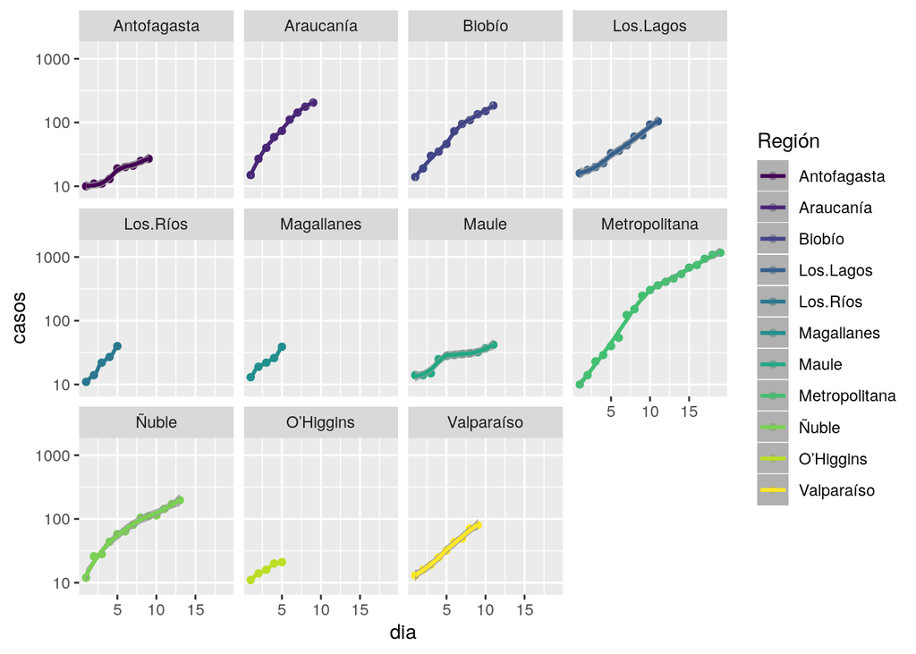

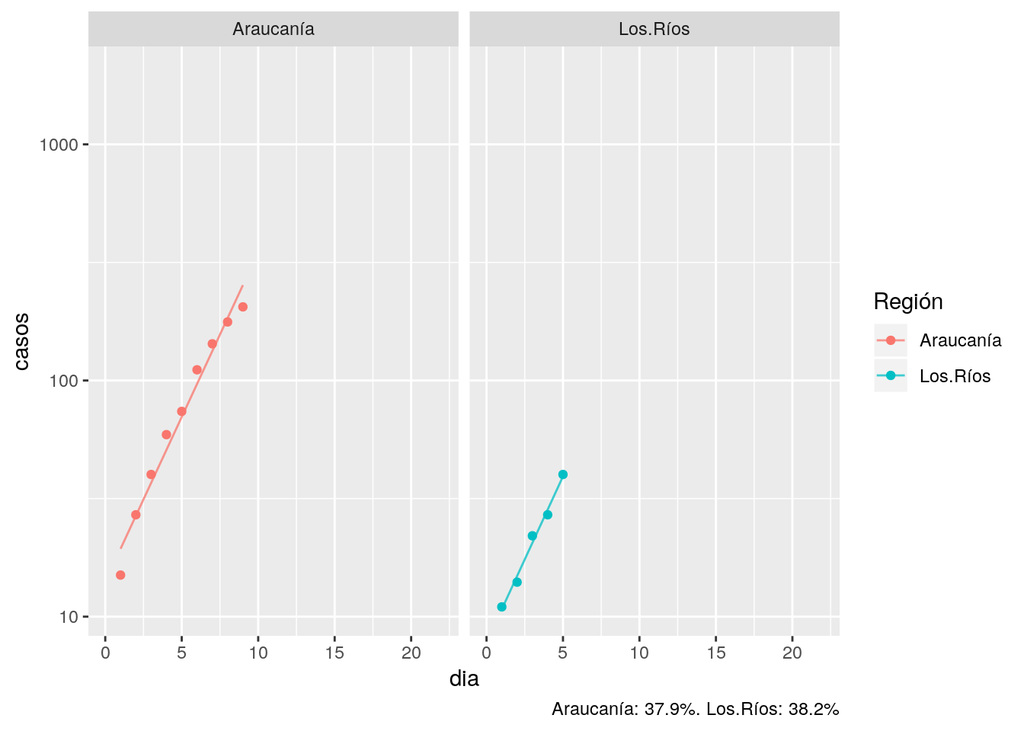

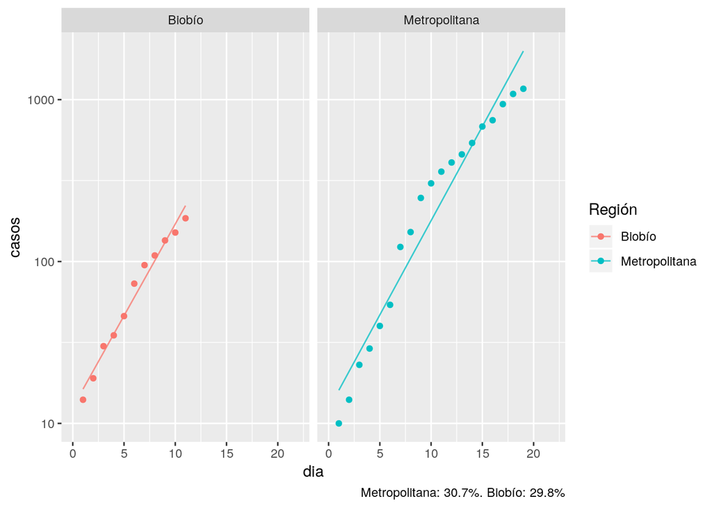

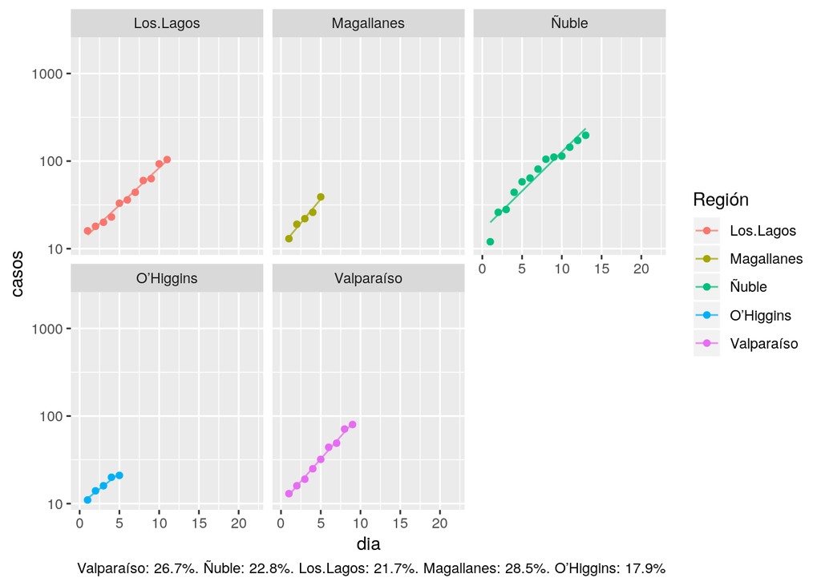

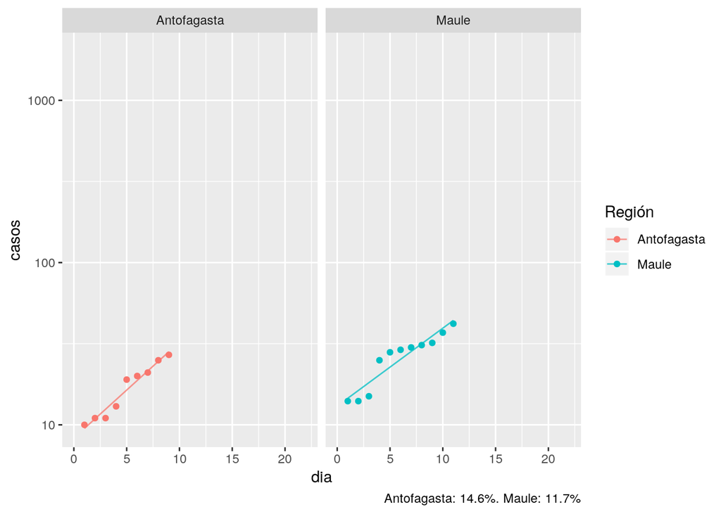

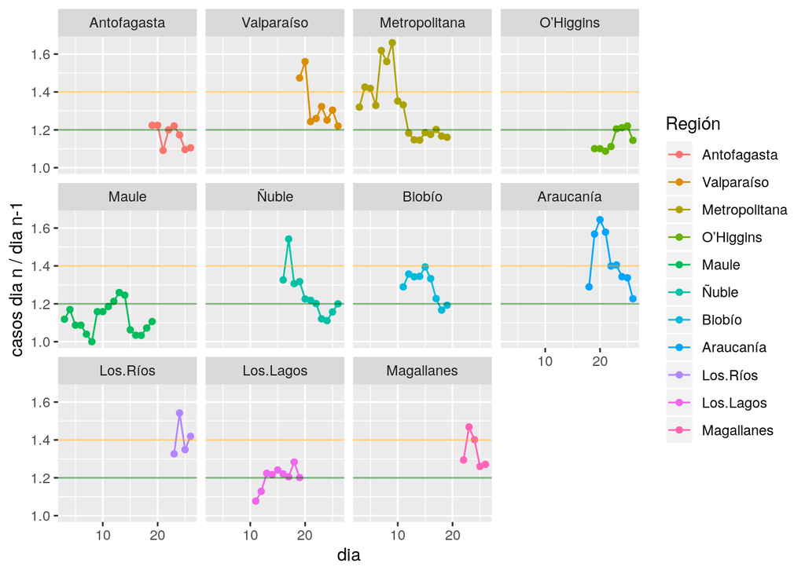

## Predicción

**NOTA**: Se presentan aquí tres metodologías de predicción. Recuerden que corresponden a un ejercicio para mostrar las bondades y dificultades de cada técnica

Para predecir, se ocupan tres técnicas distintas:

- regresión exponencial sobre datos totales: se ajusta la serie a la expresión $y=a * r^t$ usando regresión lineal. Es válida si el proceso no cambia a lo largo del tiempo. Se caracteriza porque el intervalo de confianza es constante al transformar los datos a logaritmo.
- tendencia sobre casos nuevos + AR(1): Se modela la tendencia de los casos nuevos usando regresión exponencial, más la relación que existe entre dos mediciones contiguas. El error estándar aumenta de manera importante a lo largo del tiempo, tanto por el error al calcular la tendencia, como por el componente AR(1). El valor medio obtenido es bastante sensible a los cambios en las mediciones finales.
- ARIMA(1,1,0) más deriva: Se ocupa un modelo autorregresivo, con diferenciación y deriva. Esto implica que se asume que los datos tienen una tendencia constante (como el modelo de regresión exponencial), y pero se modela la relación que existe entre casos contiguos (como el modelo de tendencia). Tiende a generar modelos menos variables que el de tendencia + AR(1), pero asume que la curva de crecimiento es la misma de toda la serie de datos.

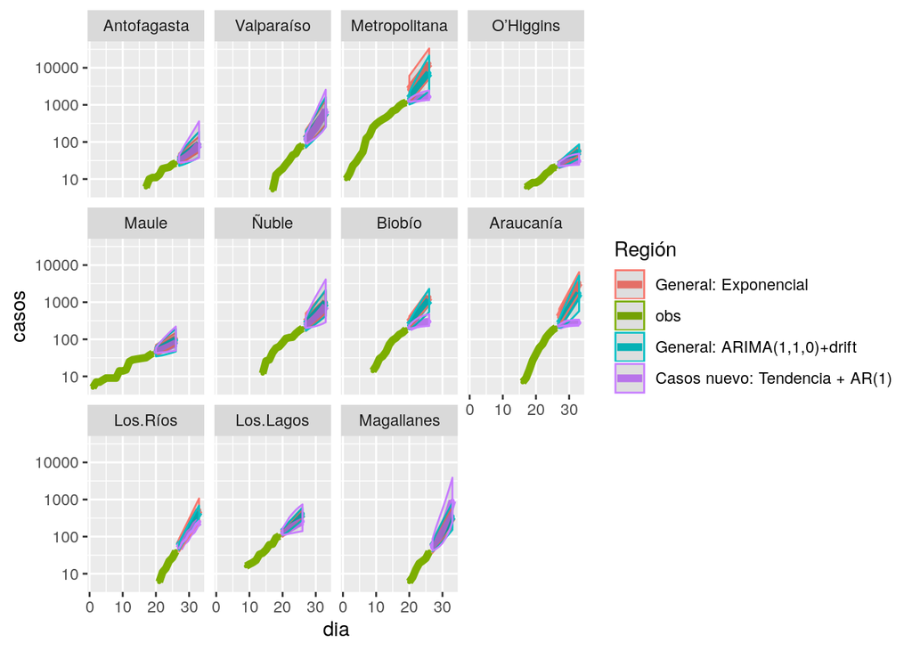

Casos nuevos: tendencia + AR(1) : Antofagasta

|  | dia | casos | li | ls |
| --- | --- | --- | --- | --- |
| **11** | 27 | 30.15 | 27.58 | 44.15 |
| **12** | 28 | 33.85 | 28.23 | 65.1 |
| **13** | 29 | 38.69 | 29.09 | 92.55 |
| **14** | 30 | 45.15 | 30.22 | 129.2 |
| **15** | 31 | 54.09 | 31.8 | 179.9 |
| **16** | 32 | 66.95 | 34.07 | 252.8 |
| **17** | 33 | 86.07 | 37.44 | 361.3 |

Casos nuevos: tendencia + AR(1) : Valparaíso

|  | dia | casos | li | ls |
| --- | --- | --- | --- | --- |
| **11** | 27 | 111.8 | 91.9 | 165.1 |
| **12** | 28 | 134.5 | 98.74 | 240.3 |
| **13** | 29 | 186.2 | 113 | 428.4 |
| **14** | 30 | 241.2 | 127.5 | 637 |
| **15** | 31 | 345.7 | 154.5 | 1041 |
| **16** | 32 | 484.4 | 190 | 1583 |
| **17** | 33 | 732.4 | 253.2 | 2557 |

Casos nuevos: tendencia + AR(1) : Metropolitana

|  | dia | casos | li | ls |
| --- | --- | --- | --- | --- |
| **20** | 20 | 1269 | 1206 | 1434 |
| **21** | 21 | 1359 | 1240 | 1670 |
| **22** | 22 | 1438 | 1270 | 1880 |
| **23** | 23 | 1507 | 1296 | 2061 |
| **24** | 24 | 1564 | 1318 | 2213 |
| **25** | 25 | 1611 | 1336 | 2336 |
| **26** | 26 | 1648 | 1350 | 2434 |

Casos nuevos: tendencia + AR(1) : O’Higgins

|  | dia | casos | li | ls |
| --- | --- | --- | --- | --- |
| **11** | 27 | 23.96 | 22.13 | 28.77 |
| **12** | 28 | 25.47 | 22.65 | 33.15 |
| **13** | 29 | 27.13 | 23.2 | 38.12 |
| **14** | 30 | 28.31 | 23.6 | 41.66 |
| **15** | 31 | 29.28 | 23.92 | 44.57 |
| **16** | 32 | 29.97 | 24.15 | 46.64 |
| **17** | 33 | 30.46 | 24.31 | 48.11 |

Casos nuevos: tendencia + AR(1) : Maule

|  | dia | casos | li | ls |
| --- | --- | --- | --- | --- |
| **20** | 20 | 45.5 | 42.73 | 58.86 |
| **21** | 21 | 49.29 | 43.51 | 77.25 |
| **22** | 22 | 53.6 | 44.4 | 98.14 |
| **23** | 23 | 58.55 | 45.42 | 122.1 |
| **24** | 24 | 64.29 | 46.6 | 149.9 |
| **25** | 25 | 70.97 | 47.98 | 182.3 |
| **26** | 26 | 78.84 | 49.6 | 220.5 |

Casos nuevos: tendencia + AR(1) : Ñuble

|  | dia | casos | li | ls |
| --- | --- | --- | --- | --- |
| **14** | 27 | 227 | 201.8 | 386.7 |
| **15** | 28 | 265.9 | 207.7 | 641.1 |
| **16** | 29 | 316.7 | 215.4 | 974.6 |
| **17** | 30 | 384.8 | 225.8 | 1421 |
| **18** | 31 | 478 | 240 | 2033 |
| **19** | 32 | 608.4 | 259.9 | 2888 |
| **20** | 33 | 794.6 | 288.3 | 4109 |

Casos nuevos: tendencia + AR(1) : Biobío

|  | dia | casos | li | ls |
| --- | --- | --- | --- | --- |
| **12** | 20 | 205.6 | 193.4 | 235.3 |
| **13** | 21 | 228.3 | 202.2 | 293.7 |
| **14** | 22 | 247.7 | 209.7 | 343.9 |
| **15** | 23 | 264.8 | 216.4 | 388.3 |
| **16** | 24 | 279.1 | 221.9 | 425.1 |
| **17** | 25 | 290.5 | 226.3 | 454.8 |
| **18** | 26 | 299.4 | 229.7 | 477.8 |

Casos nuevos: tendencia + AR(1) : Araucanía

|  | dia | casos | li | ls |
| --- | --- | --- | --- | --- |
| **12** | 27 | 229.6 | 218.9 | 248.5 |
| **13** | 28 | 248.2 | 229.2 | 282.1 |
| **14** | 29 | 261.3 | 236.4 | 305.8 |
| **15** | 30 | 269.7 | 241.1 | 321 |
| **16** | 31 | 274.7 | 243.9 | 330 |
| **17** | 32 | 277.4 | 245.4 | 334.9 |
| **18** | 33 | 278.7 | 246.1 | 337.3 |

Casos nuevos: tendencia + AR(1) : Los.Ríos

|  | dia | casos | li | ls |
| --- | --- | --- | --- | --- |
| **7** | 27 | 48.33 | 48.06 | 48.6 |
| **8** | 28 | 70.07 | 68.83 | 71.37 |
| **9** | 29 | 84.11 | 82.11 | 86.22 |
| **10** | 30 | 121.1 | 116.7 | 125.6 |
| **11** | 31 | 145.1 | 139.1 | 151.5 |
| **12** | 32 | 208.9 | 198 | 220.5 |
| **13** | 33 | 250.7 | 236.4 | 266.1 |

Casos nuevos: tendencia + AR(1) : Los.Lagos

|  | dia | casos | li | ls |
| --- | --- | --- | --- | --- |
| **12** | 20 | 124.3 | 110.4 | 168.1 |
| **13** | 21 | 140.9 | 114.7 | 233.2 |
| **14** | 22 | 163.1 | 119.9 | 327.6 |
| **15** | 23 | 184 | 124.7 | 419.3 |
| **16** | 24 | 207.9 | 130 | 525.4 |
| **17** | 25 | 231.1 | 135.2 | 629.5 |
| **18** | 26 | 255.4 | 140.6 | 738.3 |

Casos nuevos: tendencia + AR(1) : Magallanes

|  | dia | casos | li | ls |
| --- | --- | --- | --- | --- |
| **8** | 27 | 50.26 | 41.68 | 86.25 |
| **9** | 28 | 69.88 | 46.22 | 171.1 |
| **10** | 29 | 101.8 | 53.59 | 309 |
| **11** | 30 | 158.3 | 66.66 | 554 |
| **12** | 31 | 264.6 | 91.2 | 1014 |
| **13** | 32 | 476.9 | 140.2 | 1933 |
| **14** | 33 | 928 | 244.5 | 3886 |

Exponencial : Antofagasta

|  | dia | casos | li | ls |
| --- | --- | --- | --- | --- |
| **11** | 27 | 34.49 | 24.32 | 48.91 |
| **12** | 28 | 40.22 | 27.89 | 58.01 |
| **13** | 29 | 46.9 | 31.91 | 68.93 |
| **14** | 30 | 54.69 | 36.46 | 82.04 |
| **15** | 31 | 63.78 | 41.6 | 97.77 |
| **16** | 32 | 74.37 | 47.41 | 116.7 |
| **17** | 33 | 86.73 | 53.97 | 139.3 |

Exponencial : Valparaíso

|  | dia | casos | li | ls |
| --- | --- | --- | --- | --- |
| **11** | 27 | 121.1 | 68.83 | 212.9 |
| **12** | 28 | 159.2 | 88.07 | 287.8 |
| **13** | 29 | 209.4 | 112.4 | 390.2 |
| **14** | 30 | 275.4 | 143 | 530.4 |
| **15** | 31 | 362.2 | 181.5 | 722.6 |
| **16** | 32 | 476.3 | 230 | 986.2 |
| **17** | 33 | 626.4 | 291 | 1348 |

Exponencial : Metropolitana

|  | dia | casos | li | ls |
| --- | --- | --- | --- | --- |
| **20** | 20 | 2608 | 1118 | 6082 |
| **21** | 21 | 3409 | 1444 | 8052 |
| **22** | 22 | 4457 | 1862 | 10671 |
| **23** | 23 | 5827 | 2399 | 14155 |
| **24** | 24 | 7619 | 3088 | 18794 |
| **25** | 25 | 9960 | 3972 | 24975 |
| **26** | 26 | 13022 | 5105 | 33215 |

Exponencial : O’Higgins

|  | dia | casos | li | ls |
| --- | --- | --- | --- | --- |
| **11** | 27 | 24.37 | 19.64 | 30.24 |
| **12** | 28 | 28.18 | 22.47 | 35.34 |
| **13** | 29 | 32.58 | 25.68 | 41.34 |
| **14** | 30 | 37.68 | 29.33 | 48.41 |
| **15** | 31 | 43.57 | 33.46 | 56.74 |
| **16** | 32 | 50.38 | 38.14 | 66.55 |
| **17** | 33 | 58.26 | 43.46 | 78.1 |

Exponencial : Maule

|  | dia | casos | li | ls |
| --- | --- | --- | --- | --- |
| **20** | 20 | 50.21 | 35.67 | 70.7 |
| **21** | 21 | 56.52 | 39.94 | 79.99 |
| **22** | 22 | 63.62 | 44.71 | 90.53 |
| **23** | 23 | 71.62 | 50.04 | 102.5 |
| **24** | 24 | 80.61 | 55.97 | 116.1 |
| **25** | 25 | 90.74 | 62.59 | 131.6 |
| **26** | 26 | 102.1 | 69.97 | 149.1 |

Exponencial : Ñuble

|  | dia | casos | li | ls |
| --- | --- | --- | --- | --- |
| **14** | 27 | 289.6 | 166.3 | 504.4 |
| **15** | 28 | 355.8 | 200.9 | 630.1 |
| **16** | 29 | 437 | 242.2 | 788.4 |
| **17** | 30 | 536.8 | 291.7 | 987.9 |
| **18** | 31 | 659.4 | 350.8 | 1240 |
| **19** | 32 | 810 | 421.3 | 1557 |
| **20** | 33 | 995 | 505.5 | 1959 |

Exponencial : Biobío

|  | dia | casos | li | ls |
| --- | --- | --- | --- | --- |
| **12** | 20 | 287.4 | 197.8 | 417.7 |
| **13** | 21 | 373.2 | 252.9 | 550.6 |
| **14** | 22 | 484.4 | 322.9 | 726.9 |
| **15** | 23 | 628.9 | 411.5 | 961.2 |
| **16** | 24 | 816.5 | 523.9 | 1272 |
| **17** | 25 | 1060 | 666.1 | 1686 |
| **18** | 26 | 1376 | 846.2 | 2237 |

Exponencial : Araucanía

|  | dia | casos | li | ls |
| --- | --- | --- | --- | --- |
| **12** | 27 | 395.9 | 237.3 | 660.5 |
| **13** | 28 | 564.5 | 331.4 | 961.5 |
| **14** | 29 | 804.7 | 461.6 | 1403 |
| **15** | 30 | 1147 | 641.8 | 2051 |
| **16** | 31 | 1636 | 890.8 | 3003 |
| **17** | 32 | 2332 | 1234 | 4405 |
| **18** | 33 | 3324 | 1708 | 6468 |

Exponencial : Los.Ríos

|  | dia | casos | li | ls |
| --- | --- | --- | --- | --- |
| **7** | 27 | 59.18 | 39.81 | 87.96 |
| **8** | 28 | 84.9 | 54.56 | 132.1 |
| **9** | 29 | 121.8 | 74.35 | 199.5 |
| **10** | 30 | 174.7 | 100.9 | 302.5 |
| **11** | 31 | 250.7 | 136.6 | 460 |
| **12** | 32 | 359.6 | 184.5 | 701 |
| **13** | 33 | 515.9 | 248.8 | 1070 |

Exponencial : Los.Lagos

|  | dia | casos | li | ls |
| --- | --- | --- | --- | --- |
| **12** | 20 | 123.9 | 99.17 | 154.9 |
| **13** | 21 | 150.8 | 119.6 | 190.2 |
| **14** | 22 | 183.5 | 144 | 233.8 |
| **15** | 23 | 223.2 | 173.3 | 287.6 |
| **16** | 24 | 271.6 | 208.4 | 354 |
| **17** | 25 | 330.5 | 250.5 | 436.1 |
| **18** | 26 | 402.1 | 300.8 | 537.4 |

Exponencial : Magallanes

|  | dia | casos | li | ls |
| --- | --- | --- | --- | --- |
| **8** | 27 | 53.76 | 36.48 | 79.24 |
| **9** | 28 | 72.83 | 47.72 | 111.2 |
| **10** | 29 | 98.66 | 62.17 | 156.6 |
| **11** | 30 | 133.6 | 80.74 | 221.2 |
| **12** | 31 | 181 | 104.6 | 313.4 |
| **13** | 32 | 245.2 | 135.2 | 444.7 |
| **14** | 33 | 332.2 | 174.6 | 632.1 |

ARIMA(1,1,0) con deriva : Antofagasta

|  | dia | casos | li | ls |
| --- | --- | --- | --- | --- |
| **11** | 27 | 32.31 | 22.72 | 45.94 |
| **12** | 28 | 37.86 | 24.13 | 59.41 |
| **13** | 29 | 44.56 | 26 | 76.36 |
| **14** | 30 | 52.4 | 28.39 | 96.72 |
| **15** | 31 | 61.63 | 31.24 | 121.6 |
| **16** | 32 | 72.48 | 34.59 | 151.9 |
| **17** | 33 | 85.25 | 38.47 | 188.9 |

ARIMA(1,1,0) con deriva : Valparaíso

|  | dia | casos | li | ls |
| --- | --- | --- | --- | --- |
| **11** | 27 | 117.3 | 70.68 | 194.8 |
| **12** | 28 | 148.4 | 85.33 | 258 |
| **13** | 29 | 204 | 104.1 | 399.6 |
| **14** | 30 | 267.5 | 128.5 | 556.8 |
| **15** | 31 | 360.2 | 160.4 | 809.2 |
| **16** | 32 | 478 | 200.6 | 1139 |
| **17** | 33 | 639.5 | 252.6 | 1619 |

ARIMA(1,1,0) con deriva : Metropolitana

|  | dia | casos | li | ls |
| --- | --- | --- | --- | --- |
| **20** | 20 | 1483 | 1026 | 2144 |
| **21** | 21 | 1924 | 1104 | 3352 |
| **22** | 22 | 2503 | 1247 | 5024 |
| **23** | 23 | 3258 | 1443 | 7355 |
| **24** | 24 | 4240 | 1694 | 10608 |
| **25** | 25 | 5518 | 2011 | 15142 |
| **26** | 26 | 7181 | 2404 | 21446 |

ARIMA(1,1,0) con deriva : O’Higgins

|  | dia | casos | li | ls |
| --- | --- | --- | --- | --- |
| **11** | 27 | 24.14 | 20.47 | 28.46 |
| **12** | 28 | 27.74 | 21.97 | 35.02 |
| **13** | 29 | 31.88 | 23.97 | 42.42 |
| **14** | 30 | 36.65 | 26.35 | 50.96 |
| **15** | 31 | 42.12 | 29.13 | 60.89 |
| **16** | 32 | 48.41 | 32.33 | 72.49 |
| **17** | 33 | 55.64 | 35.97 | 86.06 |

ARIMA(1,1,0) con deriva : Maule

|  | dia | casos | li | ls |
| --- | --- | --- | --- | --- |
| **20** | 20 | 47.08 | 34.61 | 64.05 |
| **21** | 21 | 52.9 | 35.59 | 78.63 |
| **22** | 22 | 59.42 | 36.97 | 95.49 |
| **23** | 23 | 66.74 | 38.88 | 114.6 |
| **24** | 24 | 74.96 | 41.17 | 136.5 |
| **25** | 25 | 84.2 | 43.84 | 161.7 |
| **26** | 26 | 94.58 | 46.86 | 190.9 |

ARIMA(1,1,0) con deriva : Ñuble

|  | dia | casos | li | ls |
| --- | --- | --- | --- | --- |
| **14** | 27 | 254.8 | 169.4 | 383 |
| **15** | 28 | 313.6 | 195.2 | 503.8 |
| **16** | 29 | 393.8 | 223.6 | 693.6 |
| **17** | 30 | 490.5 | 260.6 | 923.2 |
| **18** | 31 | 613 | 305.3 | 1231 |
| **19** | 32 | 765.1 | 359.8 | 1627 |
| **20** | 33 | 955.4 | 425.7 | 2144 |

ARIMA(1,1,0) con deriva : Biobío

|  | dia | casos | li | ls |
| --- | --- | --- | --- | --- |
| **12** | 20 | 238.5 | 185 | 307.5 |
| **13** | 21 | 308.6 | 212.6 | 448 |
| **14** | 22 | 399.5 | 251.6 | 634.4 |
| **15** | 23 | 517.1 | 302.1 | 885.2 |
| **16** | 24 | 669.4 | 366.1 | 1224 |
| **17** | 25 | 866.5 | 446.6 | 1681 |
| **18** | 26 | 1122 | 547.5 | 2298 |

ARIMA(1,1,0) con deriva : Araucanía

|  | dia | casos | li | ls |
| --- | --- | --- | --- | --- |
| **12** | 27 | 263.5 | 200.7 | 346 |
| **13** | 28 | 353.3 | 221.1 | 564.5 |
| **14** | 29 | 481.6 | 255.7 | 907.1 |
| **15** | 30 | 661.1 | 305.2 | 1432 |
| **16** | 31 | 909.9 | 371.9 | 2226 |
| **17** | 32 | 1254 | 459.9 | 3418 |
| **18** | 33 | 1728 | 574.7 | 5197 |

ARIMA(1,1,0) con deriva : Los.Ríos

|  | dia | casos | li | ls |
| --- | --- | --- | --- | --- |
| **7** | 27 | 55.01 | 43.81 | 69.07 |
| **8** | 28 | 80.53 | 63.95 | 101.4 |
| **9** | 29 | 111.9 | 82.61 | 151.5 |
| **10** | 30 | 162.4 | 119.2 | 221.3 |
| **11** | 31 | 227.2 | 159.2 | 324.2 |
| **12** | 32 | 327.8 | 227.6 | 472.1 |
| **13** | 33 | 460.9 | 309.5 | 686.4 |

ARIMA(1,1,0) con deriva : Los.Lagos

|  | dia | casos | li | ls |
| --- | --- | --- | --- | --- |
| **12** | 20 | 132 | 107.4 | 162.2 |
| **13** | 21 | 156 | 124.6 | 195.3 |
| **14** | 22 | 191.9 | 146.1 | 252.2 |
| **15** | 23 | 230.9 | 171.4 | 310.9 |
| **16** | 24 | 281.2 | 202.5 | 390.6 |
| **17** | 25 | 340.2 | 239.1 | 483.9 |
| **18** | 26 | 413.1 | 283.3 | 602.3 |

ARIMA(1,1,0) con deriva : Magallanes

|  | dia | casos | li | ls |
| --- | --- | --- | --- | --- |
| **8** | 27 | 53.67 | 39.88 | 72.22 |
| **9** | 28 | 73.41 | 47.53 | 113.4 |
| **10** | 29 | 100.4 | 58.54 | 172.1 |
| **11** | 30 | 137.2 | 73.35 | 256.8 |
| **12** | 31 | 187.6 | 92.9 | 379 |
| **13** | 32 | 256.5 | 118.5 | 555.1 |
| **14** | 33 | 350.8 | 152.1 | 808.6 |

# Suma total

Excluyendo las Regiones de Arica y Parinacota, Tarapacá, Atacama, Coquimbo y Aysén, podemos tratar de calcular la suma de casos para la próxima semana. No he calculado los intervalos de confianza, porque para que sean adecuados debería considerar la covarianza entre las series de las distintas regiones.

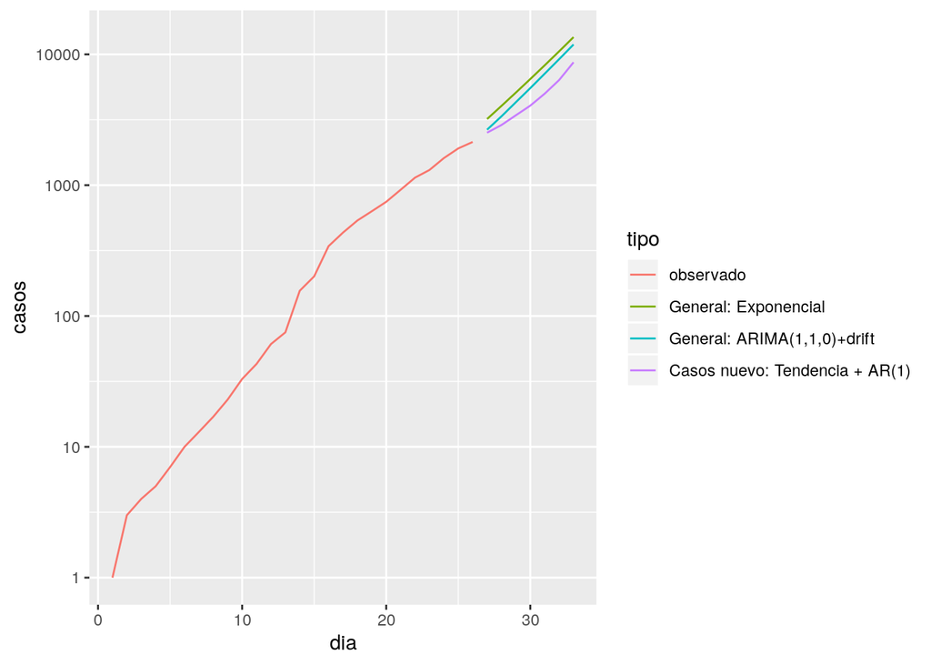

| dia | tipo | casos |
| --- | --- | --- |
| 1 | observado | 1 |
| 2 | observado | 3 |
| 3 | observado | 4 |
| 4 | observado | 5 |
| 5 | observado | 7 |
| 6 | observado | 10 |
| 7 | observado | 13 |
| 8 | observado | 17 |
| 9 | observado | 23 |
| 10 | observado | 33 |
| 11 | observado | 43 |
| 12 | observado | 61 |
| 13 | observado | 75 |
| 14 | observado | 156 |
| 15 | observado | 201 |
| 16 | observado | 342 |
| 17 | observado | 434 |
| 18 | observado | 537 |
| 19 | observado | 632 |
| 20 | observado | 746 |
| 21 | observado | 922 |
| 22 | observado | 1142 |
| 23 | observado | 1306 |
| 24 | observado | 1610 |
| 25 | observado | 1909 |
| 26 | observado | 2139 |
| 27 | General: Exponencial | 3202 |
| 28 | General: Exponencial | 4036 |
| 29 | General: Exponencial | 5103 |
| 30 | General: Exponencial | 6475 |
| 31 | General: Exponencial | 8246 |
| 32 | General: Exponencial | 10541 |
| 33 | General: Exponencial | 13528 |
| 27 | General: ARIMA(1,1,0)+drift | 2654 |
| 28 | General: ARIMA(1,1,0)+drift | 3358 |
| 29 | General: ARIMA(1,1,0)+drift | 4308 |
| 30 | General: ARIMA(1,1,0)+drift | 5518 |
| 31 | General: ARIMA(1,1,0)+drift | 7115 |
| 32 | General: ARIMA(1,1,0)+drift | 9179 |
| 33 | General: ARIMA(1,1,0)+drift | 11890 |
| 27 | Casos nuevo: Tendencia + AR(1) | 2517 |
| 28 | Casos nuevo: Tendencia + AR(1) | 2883 |
| 29 | Casos nuevo: Tendencia + AR(1) | 3421 |
| 30 | Casos nuevo: Tendencia + AR(1) | 4055 |
| 31 | Casos nuevo: Tendencia + AR(1) | 5006 |
| 32 | Casos nuevo: Tendencia + AR(1) | 6359 |
| 33 | Casos nuevo: Tendencia + AR(1) | 8690 |

**Fuentes de información**: Principalmente, se utilizó el reporte diario del [MINSAL](https://www.minsal.cl/nuevo-coronavirus-2019-ncov/casos-confirmados-en-chile-covid-19/), usando [Wayback machine](https://archive.org/web/) para recopilar la información ya no disponible.